# Práctica 3. Mapeo de secuencias cortas

Última actualización:

10 de mayo de 2026

# 1 Introducción

En esta práctica se trabaja con un flujo básico de análisis de lecturas cortas de secuenciación: descarga de datos FASTQ, control de calidad, filtrado, alineamiento frente a un genoma de referencia, cálculo de estadísticas de cobertura e identificación de variantes. El objetivo no es únicamente ejecutar programas externos, sino comprender qué archivo produce cada paso y cómo se encadenan los resultados hasta obtener un archivo de variantes en formato VCF.

El flujo general seguido es:

1. descargar lecturas cortas paired-end y un genoma de referencia;
2. evaluar y filtrar la calidad de las lecturas con `fastp`;
3. alinear las lecturas al genoma con `bwa mem`;
4. convertir, ordenar e indexar alineamientos con `samtools`;
5. revisar estadísticas de cobertura;
6. detectar variantes con `freebayes`.

**ImportanteReproducibilidad**

Los bloques de código están escritos de forma condicional: si un archivo de salida ya existe, no se vuelve a generar. Esto evita repetir descargas o procesos largos cada vez que se renderiza el documento. Aun así, el `.qmd` conserva el código necesario para regenerar los resultados desde cero en un entorno con las herramientas instaladas.

# 2 Preparación

Usaremos los programas siguientes:

- [`fastp`](https://github.com/OpenGene/fastp) (Chen et al. 2018), para control de calidad, recorte y filtrado de lecturas cortas.
- [`bwa`](https://github.com/lh3/bwa) (Li y Durbin 2009), para mapear lecturas cortas frente a un genoma de referencia.
- [`samtools`](https://www.htslib.org/) (Danecek et al. 2021), para convertir, ordenar, indexar y resumir archivos SAM/BAM.
- [`freebayes`](https://github.com/freebayes/freebayes/releases) (Garrison y Marth 2012), para identificar variantes a partir del archivo BAM.

En sistemas Linux, algunos programas pueden instalarse con paquetes del sistema, por ejemplo:

```bash
# Este bloque sólo comprueba si los programas están disponibles.
# No instala software, porque la instalación depende de los permisos del sistema.
for programa in wget bwa samtools freebayes; do
   if command -v $programa >/dev/null 2>&1; then
      echo "$programa: disponible ($(command -v $programa))"
   else
      echo "$programa: NO encontrado en el PATH"
   fi
done

if command -v fastp >/dev/null 2>&1; then
   echo "fastp: disponible ($(command -v fastp))"
elif [ -x ./fastp ]; then
   echo "fastp: disponible como ./fastp"
else
   echo "fastp: NO encontrado; se intentará descargar más adelante si hace falta"
fi
```

```
wget: disponible (/usr/bin/wget)
bwa: disponible (/usr/bin/bwa)
samtools: disponible (/usr/bin/samtools)
freebayes: NO encontrado en el PATH
fastp: disponible (/usr/bin/fastp)
```

Si `fastp` no está instalado en el sistema, puede descargarse un ejecutable en la carpeta actual y concederle permiso de ejecución. El bloque siguiente sólo lo descarga si no encuentra ni `fastp` en el `PATH` ni `./fastp` en la carpeta de trabajo.

```bash
if ! command -v fastp >/dev/null 2>&1 && [ ! -x ./fastp ]; then
   echo "Descargando fastp en la carpeta de trabajo..."
   wget -q -O fastp http://opengene.org/fastp/fastp
   chmod u+x ./fastp
fi

if command -v fastp >/dev/null 2>&1; then
   fastp -v
elif [ -x ./fastp ]; then
   ./fastp -v
else
   echo "No se ha podido preparar fastp. Revisa la conexión o la instalación."
fi
```

```
fastp 0.20.1
```

**NotaNota sobre `bwa`**

El programa `bwa` puede instalarse mediante el gestor de paquetes del sistema o compilando el código fuente:

```bash
git clone https://github.com/lh3/bwa.git
cd bwa
make
```

Después, el ejecutable debe estar disponible en una carpeta del `PATH`, o bien invocarse mediante su ruta completa.

# 3 Objetivos

1. Realizar control de calidad de lecturas cortas.
2. Mapear lecturas cortas a un genoma de referencia.
3. Obtener estadísticas del alineamiento.
4. Identificar variantes respecto al genoma de referencia.
5. Interpretar los resultados de forma reproducible.

# 4 Datos

A continuación descargamos un par de archivos FASTQ de la base de datos [ENA](https://www.ebi.ac.uk/ena/browser/home). Han sido seleccionados porque su tamaño comprimido no supera los 100 MB. Son secuencias de la cepa Tsu4-125 de *Bradyrhizobium japonicum*, una bacteria simbionte de la planta de soja. Proceden de la Universidad de Tohoku y forman parte de un proyecto en el que se secuenciaron distintas cepas de *Bradyrhizobium*.

Los datos de partida son lecturas paired-end, por lo que cada fragmento de ADN queda representado por dos archivos: una lectura forward (`R1`) y una lectura reverse (`R2`).

```bash
if [ ! -e DRR025089_1.fastq.gz ]; then
   wget -q \
      ftp://ftp.sra.ebi.ac.uk/vol1/fastq/DRR025/DRR025089/DRR025089_1.fastq.gz
fi

if [ ! -e DRR025089_2.fastq.gz ]; then
   wget -q \
      ftp://ftp.sra.ebi.ac.uk/vol1/fastq/DRR025/DRR025089/DRR025089_2.fastq.gz
fi

ls -lh DRR025089_1.fastq.gz DRR025089_2.fastq.gz 2>/dev/null || true
```

```
-rw-r--r-- 1 laumonv4 usuarios^del^dominio 72M may 10 10:10 DRR025089_1.fastq.gz
-rw-r--r-- 1 laumonv4 usuarios^del^dominio 71M may 10 10:10 DRR025089_2.fastq.gz
```

## 4.1 Inspección inicial de los FASTQ

Para revisar de forma rápida los archivos comprimidos sin descomprimirlos completamente, se puede usar `zcat`, `zless` o `gunzip -c`. Como cada lectura FASTQ ocupa cuatro líneas, el número de lecturas puede estimarse dividiendo el número total de líneas entre cuatro.

```bash
if [ -e DRR025089_1.fastq.gz ]; then
   echo "Primeras líneas de DRR025089_1.fastq.gz:"
   zcat DRR025089_1.fastq.gz | head -8

   echo "Número aproximado de lecturas en R1:"
   echo $(( $(zcat DRR025089_1.fastq.gz | wc -l) / 4 ))
fi

if [ -e DRR025089_2.fastq.gz ]; then
   echo "Número aproximado de lecturas en R2:"
   echo $(( $(zcat DRR025089_2.fastq.gz | wc -l) / 4 ))
fi
```

```
Primeras líneas de DRR025089_1.fastq.gz:
@DRR025089.1 1/1
NGCGTGACGCCGCGTCGACGCCATGATCCGGCTCGGTGTTGAAACCGAGTCACAGAGCCA…
+
#>>AAAAAAA?@EAAEA0/EEEEFHFF1E0A?EEGE/?EEG2@GGH/E@FHFBGFBCFABFEGFEAGFE?EGEFFHHGHGECC/C--<111FC1<C<.<-<A<--:0</@C.;.:00<90.;A-..;00:;?--@?B-A/-----/////--;9--;B-E-9A9---------;-----9F//9///9-///#-9--##---9#-;####;;###;9####;-###-####---##------------//9
@DRR025089.2 2/1
NATCGGTCAAGCCCGGCGATCCCTGCGCGAGGAACCATGAGCGCGGTCCGGATCACGCGA…
+
#>3>ABBBBFFFGGGGGGGGGGHHHHGGGGGGGHHGGGHHHHGGGGEGEGFAEGFHGHGGGGGHGGGGGDGGGGGGHHGHHECHGGGGG?FGHHHGDDGGHHGGHEGGHGCFGGGGGGGGGGDFFFFFFFFFFFFFFFFFFFFFFFFDFDFEFFFFFF?DFFADBAFFFFFFFFF;=9--;B-=DCAAFFFB#..:;##;9.##;.####9;###..####..###9####...##.9...;------:;
Número aproximado de lecturas en R1:
411682
Número aproximado de lecturas en R2:
411682
```

**NotaDesafío**

Una vez descargados los archivos FASTQ, échales un vistazo desde la línea de órdenes. Puedes hacerlo con `zless`, una versión de `less` capaz de mostrar archivos comprimidos, o bien descomprimiendo los archivos con `gunzip`. Para no ocupar espacio de disco innecesariamente, puedes usar `gunzip -c DRR025089_1.fastq.gz | less -S`, que envía el contenido del archivo a la salida estándar, de donde `less -S` lo lee, sin modificar nada en la carpeta. ¿Sabrías contar el número de líneas de cada archivo?

He comprobado los archivos FASTQ con comandos de Bash sin descomprimirlos de forma permanente. Como cada registro FASTQ ocupa cuatro líneas, el número de lecturas se obtiene dividiendo el número total de líneas entre cuatro. Esta comprobación es útil para confirmar que ambos archivos paired-end contienen un número coherente de lecturas.

# 5 Genoma de referencia

Necesitaremos también el genoma de referencia de *Bradyrhizobium japonicum*. Usaremos el de la cepa ACCC 15027.

```bash
if [ ! -e referencia.fa ]; then
   wget -q -O referencia.fa \
      https://www.ebi.ac.uk/ena/browser/api/fasta/GCA_042137995.2
fi

ls -lh referencia.fa 2>/dev/null || true
```

```
-rw-r--r-- 1 laumonv4 usuarios^del^dominio 9,8M may 10 10:10 referencia.fa
```

**NotaPreguntas**

- ¿Crees que deberíamos guardar los archivos descargados en `../../data`?
- ¿Cómo podrías guardar los mensajes de `wget` en un archivo?
- ¿De cuántas secuencias diferentes se compone este genoma de referencia?

Sí, en un proyecto bioinformático completo sería recomendable guardar los archivos brutos o de referencia en `data/`, separándolos de los resultados generados en `results/`. Esta separación mejora la trazabilidad del análisis: los datos originales quedan diferenciados de los archivos derivados por los programas.

Una estructura típica sería:

```
bioinfo/
├── data/        # FASTQ, genomas de referencia y otros datos brutos
├── doc/         # bibliografía y documentación auxiliar
└── results/     # guiones, HTML y resultados de cada práctica
```

Los mensajes de `wget` pueden guardarse usando la opción `-o`, por ejemplo:

```bash
wget -o descarga.log -O referencia.fa URL
```

También podría usarse redirección:

```bash
wget URL > salida.log 2>&1
```

La salida estándar se redirige con `>`, mientras que `2>&1` envía también los mensajes de error al mismo archivo.

Para saber de cuántas secuencias se compone el genoma de referencia, basta con contar las cabeceras FASTA, que empiezan por `>`.

```bash
if [ -e referencia.fa ]; then
   grep -c '^>' referencia.fa
fi
```

```
3
```

En este caso, el genoma de referencia está formado por varias secuencias FASTA. Esto es esperable si el ensamblaje contiene más de una molécula, por ejemplo un cromosoma y plásmidos.

# 6 Control de calidad con `fastp`

`fastp` permite filtrar lecturas de baja calidad, recortar adaptadores, corregir pares solapantes y generar informes HTML y JSON. En este caso lo usamos para limpiar las lecturas paired-end y, además, generar un archivo con lecturas fusionadas cuando R1 y R2 se solapan.

```bash
if command -v fastp >/dev/null 2>&1; then
   FASTP=fastp
elif [ -x ./fastp ]; then
   FASTP=./fastp
else
   FASTP=""
fi

if [ -n "$FASTP" ] && [ ! -e fastp.html ]; then
   $FASTP \
      -i DRR025089_1.fastq.gz \
      -o DRR025089_1_clean.fastq \
      -I DRR025089_2.fastq.gz \
      -O DRR025089_2_clean.fastq \
      --merge \
      --merged_out DRR025089_m_clean.fastq \
      --html fastp.html \
      --json fastp.json
fi

ls -lh fastp.html fastp.json DRR025089_1_clean.fastq DRR025089_2_clean.fastq DRR025089_m_clean.fastq 2>/dev/null || true
```

```
Read1 before filtering:
total reads: 411682
total bases: 89587168
Q20 bases: 73602554(82.1575%)
Q30 bases: 65323285(72.9159%)

Read2 before filtering:
total reads: 411682
total bases: 90108666
Q20 bases: 70268524(77.982%)
Q30 bases: 61524120(68.2777%)

Merged and filtered:
total reads: 233677
total bases: 50026050
Q20 bases: 44863481(89.6802%)
Q30 bases: 41817873(83.5922%)

Filtering result:
reads passed filter: 751986
reads failed due to low quality: 70324
reads failed due to too many N: 1054
reads failed due to too short: 0
reads with adapter trimmed: 58356
bases trimmed due to adapters: 1486170
reads corrected by overlap analysis: 209536
bases corrected by overlap analysis: 690601

Duplication rate: 0.149079%

Insert size peak (evaluated by paired-end reads): 174

Read pairs merged: 233677
% of original read pairs: 56.7615%
% in reads after filtering: 100%


JSON report: fastp.json
HTML report: fastp.html

fastp -i DRR025089_1.fastq.gz -o DRR025089_1_clean.fastq -I DRR025089_2.fastq.gz -O DRR025089_2_clean.fastq --merge --merged_out DRR025089_m_clean.fastq --html fastp.html --json fastp.json
fastp v0.20.1, time used: 10 seconds
-rw-r--r-- 1 laumonv4 usuarios^del^dominio  72M may 10 10:10 DRR025089_1_clean.fastq
-rw-r--r-- 1 laumonv4 usuarios^del^dominio  73M may 10 10:10 DRR025089_2_clean.fastq
-rw-r--r-- 1 laumonv4 usuarios^del^dominio 106M may 10 10:10 DRR025089_m_clean.fastq
-rw-r--r-- 1 laumonv4 usuarios^del^dominio 381K may 10 10:10 fastp.html
-rw-r--r-- 1 laumonv4 usuarios^del^dominio 145K may 10 10:10 fastp.json
```

**NotaEjercicios**

1. Revisa la ayuda del programa ejecutando `fastp -h`, y asegúrate de entender al menos las opciones que hemos usado.
2. Revisa el informe generado por `fastp` en el archivo `fastp.html` y redacta un pequeño resumen de las principales conclusiones que sacas.
3. Descarga un segundo conjunto de archivos FASTQ de la misma especie y repite el análisis de calidad con ellos.

Las opciones principales usadas son:

- `-i`: archivo de entrada de lecturas forward (`R1`).
- `-o`: archivo de salida para `R1` tras el filtrado.
- `-I`: archivo de entrada de lecturas reverse (`R2`).
- `-O`: archivo de salida para `R2` tras el filtrado.
- `--merge`: intenta fusionar pares de lecturas solapantes.
- `--merged_out`: archivo FASTQ con las lecturas fusionadas.
- `--html`: informe visual del control de calidad.
- `--json`: informe estructurado en formato JSON.

El análisis de calidad realizado con `fastp` muestra si las lecturas originales presentan una calidad suficiente para continuar con el mapeo. En general, se espera que tras el filtrado aumente el porcentaje de bases con calidad alta, disminuya la presencia de adaptadores y se eliminen lecturas con baja calidad o con demasiadas bases ambiguas. El informe HTML de `fastp` permite revisar rápidamente la calidad por posición, el contenido GC, la presencia de adaptadores, la longitud de las lecturas y el número de lecturas filtradas.

## 6.1 Segundo conjunto de datos

Como ejercicio adicional, descargué un segundo conjunto de datos de la misma especie, correspondiente al run `DRR025091`, y repetí el análisis de calidad. Esta comparación permite comprobar si otros datos del mismo proyecto presentan características similares.

```bash
if [ ! -e DRR025091_1.fastq.gz ]; then
   wget -q \
      ftp://ftp.sra.ebi.ac.uk/vol1/fastq/DRR025/DRR025091/DRR025091_1.fastq.gz
fi

if [ ! -e DRR025091_2.fastq.gz ]; then
   wget -q \
      ftp://ftp.sra.ebi.ac.uk/vol1/fastq/DRR025/DRR025091/DRR025091_2.fastq.gz
fi

if command -v fastp >/dev/null 2>&1; then
   FASTP=fastp
elif [ -x ./fastp ]; then
   FASTP=./fastp
else
   FASTP=""
fi

if [ -n "$FASTP" ] && [ ! -e fastp_DRR025091.html ]; then
   $FASTP \
      -i DRR025091_1.fastq.gz \
      -o DRR025091_1_clean.fastq \
      -I DRR025091_2.fastq.gz \
      -O DRR025091_2_clean.fastq \
      --merge \
      --merged_out DRR025091_m_clean.fastq \
      --html fastp_DRR025091.html \
      --json fastp_DRR025091.json
fi

ls -lh fastp_DRR025091.html fastp_DRR025091.json 2>/dev/null || true
```

```
Read1 before filtering:
total reads: 492582
total bases: 110244706
Q20 bases: 96165924(87.2295%)
Q30 bases: 88210847(80.0137%)

Read2 before filtering:
total reads: 492582
total bases: 111081531
Q20 bases: 86844494(78.1809%)
Q30 bases: 75989866(68.4091%)

Merged and filtered:
total reads: 276645
total bases: 66040590
Q20 bases: 61485820(93.1031%)
Q30 bases: 58545784(88.6512%)

Filtering result:
reads passed filter: 899992
reads failed due to low quality: 83266
reads failed due to too many N: 1906
reads failed due to too short: 0
reads with adapter trimmed: 54476
bases trimmed due to adapters: 1177810
reads corrected by overlap analysis: 233860
bases corrected by overlap analysis: 694411

Duplication rate: 0.162296%

Insert size peak (evaluated by paired-end reads): 223

Read pairs merged: 276645
% of original read pairs: 56.1622%
% in reads after filtering: 100%


JSON report: fastp_DRR025091.json
HTML report: fastp_DRR025091.html

fastp -i DRR025091_1.fastq.gz -o DRR025091_1_clean.fastq -I DRR025091_2.fastq.gz -O DRR025091_2_clean.fastq --merge --merged_out DRR025091_m_clean.fastq --html fastp_DRR025091.html --json fastp_DRR025091.json
fastp v0.20.1, time used: 13 seconds
-rw-r--r-- 1 laumonv4 usuarios^del^dominio 381K may 10 10:10 fastp_DRR025091.html
-rw-r--r-- 1 laumonv4 usuarios^del^dominio 146K may 10 10:10 fastp_DRR025091.json
```

La comparación entre ambos conjuntos de datos permite valorar si la calidad de secuenciación es consistente dentro del proyecto. En mi análisis, ambos datasets presentan un comportamiento general comparable: la limpieza mejora la calidad global, el contenido GC se mantiene estable y la contaminación por adaptadores parece baja. Esto sugiere que las lecturas son adecuadas para análisis posteriores como mapeo y detección de variantes.

# 7 Mapeo

El objetivo de esta sección es alinear las lecturas cortas al genoma de referencia mediante `bwa mem`. El archivo final será un archivo BAM ordenado e indexado. Para llegar a ese archivo se generan varios productos intermedios: un índice del genoma de referencia, un archivo SAM, un archivo BAM sin ordenar, un BAM ordenado y un índice BAI.

**TipPor qué usamos condiciones `if`**

Los archivos SAM y BAM pueden ocupar bastante espacio. Por eso, el guion comprueba si el resultado final ya existe antes de regenerar pasos anteriores. Este patrón evita repetir tareas costosas y hace el documento más reproducible.

```bash
if command -v bwa >/dev/null 2>&1 && command -v samtools >/dev/null 2>&1; then

   if [ ! -e DRR025089.bam ]; then

      if [ ! -e referencia.fa.bwt ]; then
         bwa index referencia.fa
      fi

      if [ ! -e DRR025089.sam ]; then
         bwa mem -M \
            -R '@RG\tID:DRR025089\tSM:SAMD00022947' \
            -o DRR025089.sam \
            referencia.fa \
            DRR025089_1_clean.fastq \
            DRR025089_2_clean.fastq \
            1> bwa.log 2> bwa.err
      fi

      if [ ! -e DRR025089_unsorted.bam ]; then
         samtools view -b -o DRR025089_unsorted.bam DRR025089.sam
      fi

      samtools sort -o DRR025089.bam DRR025089_unsorted.bam
      samtools index DRR025089.bam
   fi

else
   echo "bwa o samtools no están disponibles; no se ejecuta el mapeo."
fi

ls -lh DRR025089.bam DRR025089.bam.bai 2>/dev/null || true
```

```
[bwa_index] Pack FASTA... 0.06 sec
[bwa_index] Construct BWT for the packed sequence...
[bwa_index] 3.02 seconds elapse.
[bwa_index] Update BWT... 0.05 sec
[bwa_index] Pack forward-only FASTA... 0.03 sec
[bwa_index] Construct SA from BWT and Occ... 1.26 sec
[main] Version: 0.7.17-r1188
[main] CMD: bwa index referencia.fa
[main] Real time: 6.922 sec; CPU: 4.420 sec
-rw-r--r-- 1 laumonv4 usuarios^del^dominio 60M may 10 10:12 DRR025089.bam
-rw-r--r-- 1 laumonv4 usuarios^del^dominio 23K may 10 10:12 DRR025089.bam.bai
```

**NotaDesafíos**

1. Entre las órdenes anteriores, añade la descarga del genoma de referencia en el lugar adecuado y bajo la condición adecuada para que pueda borrarse una vez se haya generado el alineamiento.
2. En un bloque de órdenes nuevo, alinea también los pares de lecturas cortas que `fastp` había combinado (`DRR025089_m_clean.fastq`).
3. Lee la lista de funciones que te ofrece `samtools` al ejecutarlo sin ningún argumento. ¿Qué función usarías para combinar dos archivos BAM en uno?
4. ¿Cuánto espacio de disco ocupan los archivos FASTQ, el genoma de referencia y su índice y el archivo SAM?
5. ¿Crees que hay algún inconveniente al usar tuberías?

La descarga del genoma de referencia debe situarse antes de `bwa index`, porque el índice sólo puede construirse si `referencia.fa` existe. El bloque ya lo realiza bajo la condición `if [ ! -e referencia.fa ]`, de forma que el archivo se descarga únicamente si no estaba disponible.

Para alinear las lecturas fusionadas por `fastp`, se puede usar `bwa mem` con un único archivo de entrada, ya que estas lecturas ya no son paired-end sino secuencias individuales resultantes del solapamiento entre R1 y R2.

```bash
if command -v bwa >/dev/null 2>&1 && command -v samtools >/dev/null 2>&1; then
   if [ -e DRR025089_m_clean.fastq ] && [ ! -e DRR025089_merged.bam ]; then
      bwa mem referencia.fa DRR025089_m_clean.fastq > DRR025089_merged.sam
      samtools view -b -o DRR025089_merged_unsorted.bam DRR025089_merged.sam
      samtools sort -o DRR025089_merged.bam DRR025089_merged_unsorted.bam
      samtools index DRR025089_merged.bam
   fi
else
   echo "bwa o samtools no están disponibles; no se alinean las lecturas fusionadas."
fi

ls -lh DRR025089_merged.bam DRR025089_merged.bam.bai 2>/dev/null || true
```

```
[M::bwa_idx_load_from_disk] read 0 ALT contigs
[M::process] read 49448 sequences (10000204 bp)...
[M::process] read 46934 sequences (10000092 bp)...
[M::mem_process_seqs] Processed 49448 reads in 10.477 CPU sec, 11.014 real sec
[M::process] read 46606 sequences (10000145 bp)...
[M::mem_process_seqs] Processed 46934 reads in 10.926 CPU sec, 11.267 real sec
[M::process] read 45872 sequences (10000188 bp)...
[M::mem_process_seqs] Processed 46606 reads in 10.720 CPU sec, 10.996 real sec
[M::process] read 44700 sequences (10000330 bp)...
[M::mem_process_seqs] Processed 45872 reads in 11.118 CPU sec, 11.728 real sec
[M::process] read 117 sequences (25091 bp)...
[M::mem_process_seqs] Processed 44700 reads in 10.905 CPU sec, 11.808 real sec
[M::mem_process_seqs] Processed 117 reads in 0.057 CPU sec, 0.038 real sec
[main] Version: 0.7.17-r1188
[main] CMD: bwa mem referencia.fa DRR025089_m_clean.fastq
[main] Real time: 65.168 sec; CPU: 54.298 sec
-rw-r--r-- 1 laumonv4 usuarios^del^dominio 40M may 10 10:13 DRR025089_merged.bam
-rw-r--r-- 1 laumonv4 usuarios^del^dominio 13K may 10 10:13 DRR025089_merged.bam.bai
```

La función adecuada para combinar varios archivos BAM es `samtools merge`. Por ejemplo:

```bash
echo "Ejemplo de uso de samtools merge:"
echo "samtools merge BAM_combinado.bam archivo1.bam archivo2.bam"
```

```
Ejemplo de uso de samtools merge:
samtools merge BAM_combinado.bam archivo1.bam archivo2.bam
```

El espacio ocupado por los archivos generados puede revisarse con `du -h` y `ls -lh`.

```bash
du -h DRR025089_1.fastq.gz DRR025089_2.fastq.gz referencia.fa DRR025089.sam DRR025089.bam 2>/dev/null || true
```

```
72M DRR025089_1.fastq.gz
71M DRR025089_2.fastq.gz
9,8M    referencia.fa
181M    DRR025089.sam
60M DRR025089.bam
```

El archivo SAM suele ocupar bastante más que el BAM porque es texto plano y almacena todos los alineamientos sin comprimir. Por esta razón, en flujos de trabajo reales suele eliminarse una vez generado el BAM ordenado e indexado.

También se podría usar una tubería para evitar crear el archivo SAM intermedio:

```bash
echo "Pipeline equivalente con tuberías:"
echo "bwa mem -M -R '@RG\\tID:DRR025089\\tSM:SAMD00022947' referencia.fa DRR025089_1_clean.fastq DRR025089_2_clean.fastq | samtools view -b | samtools sort -o DRR025089.bam"
```

```
Pipeline equivalente con tuberías:
bwa mem -M -R '@RG\tID:DRR025089\tSM:SAMD00022947' referencia.fa DRR025089_1_clean.fastq DRR025089_2_clean.fastq | samtools view -b | samtools sort -o DRR025089.bam
```

El uso de tuberías en Bash permite encadenar directamente varios programas sin generar archivos intermedios, lo que reduce el uso de espacio en disco y puede mejorar la eficiencia. Sin embargo, también dificulta la depuración: si algo falla, es menos evidente en qué paso ocurrió el problema. Además, no se conservan resultados intermedios que podrían ser útiles para revisar o reutilizar el análisis.

# 8 Estadísticas de alineamiento y cobertura

Antes de proseguir, es importante comprobar el resultado del mapeo. Podemos extraer estadísticas del archivo BAM con `samtools stats`.

```bash
if command -v samtools >/dev/null 2>&1 && [ -e DRR025089.bam ]; then
   if [ ! -e DRR025089.stats.txt ]; then
      samtools stats DRR025089.bam > DRR025089.stats.txt
   fi

   grep '^COV' DRR025089.stats.txt | cut -f 2- > COV.txt
else
   echo "No se puede generar COV.txt porque falta samtools o DRR025089.bam."
fi

ls -lh DRR025089.stats.txt COV.txt 2>/dev/null || true
```

```
-rw-r--r-- 1 laumonv4 usuarios^del^dominio  961 may 10 10:13 COV.txt
-rw-r--r-- 1 laumonv4 usuarios^del^dominio 258K may 10 10:13 DRR025089.stats.txt
```

Ahora podemos importar los datos de cobertura a una sesión de R y representarlos gráficamente.

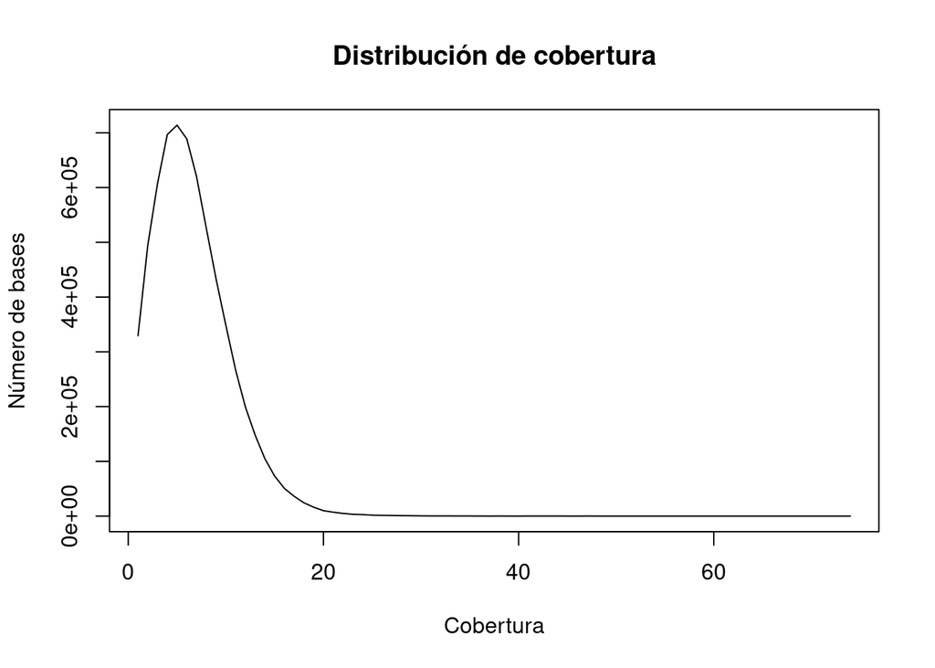

```r
if (file.exists("COV.txt") && file.info("COV.txt")$size > 0) {
  COV <- read.table("COV.txt", col.names = c("intervalo", "cobertura", "bases"))
  plot(COV$cobertura, COV$bases,
       type = "l",
       xlab = "Cobertura",
       ylab = "Número de bases",
       main = "Distribución de cobertura")
} else {
  message("No se representa la cobertura porque COV.txt no existe o está vacío.")
}
```

**NotaDesafíos**

1. La distribución de cobertura tiene una cola larga. ¿Puedes centrar la representación gráfica entre 0 y 20?
2. ¿Qué otras estadísticas crees que vale la pena revisar?
3. El genoma de referencia incluye dos plásmidos. ¿La cepa secuenciada los tiene?
4. Visualiza los alineamientos en el terminal con `samtools tview DRR025089.bam referencia.fa`.

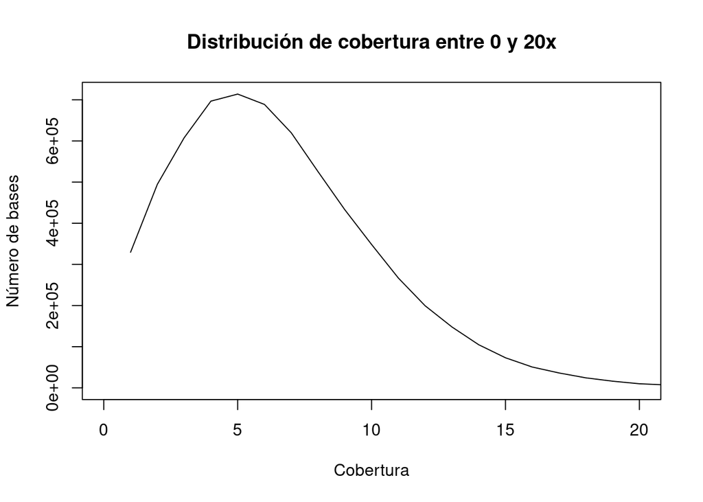

```r
if (exists("COV")) {
  plot(COV$cobertura, COV$bases,
       type = "l",
       xlim = c(0, 20),
       xlab = "Cobertura",
       ylab = "Número de bases",
       main = "Distribución de cobertura entre 0 y 20x")
}
```

Además de la distribución de cobertura, conviene revisar la cobertura media, la cobertura mediana, el porcentaje de lecturas mapeadas, el número de lecturas correctamente emparejadas, la tasa de duplicación, la calidad de mapeo y la proporción del genoma cubierta por encima de determinados umbrales. Estas métricas permiten saber si el alineamiento es suficientemente fiable para identificar variantes.

La presencia de plásmidos en la cepa secuenciada podría inferirse si las secuencias plasmídicas del genoma de referencia presentan cobertura comparable a la del cromosoma. Si los plásmidos no aparecen cubiertos o presentan cobertura casi nula, podría indicar que la cepa secuenciada no los contiene o que difiere del genoma de referencia.